# MOFA+: stochastic inference

## 2.5 Fit model using stochastic variational inference

There are three options for stochastic inference that the user can modify:  
- **batch_size**: float value indicating the batch size (as a fraction of the total data set: 0.10, 0.25 or 0.50). We recommend setting `batch_size` to the largest value that can fit into the GPU memory.  
- **learning_rate**: starting learning rate, we recommend values from 0.75 to 1.0  
- **forgetting_rate**: forgetting rate (we recommend values from 0.25 to 0.5)

```r
stochastic_opts <- get_default_stochastic_options(MOFAobject)
```

Prepare the MOFA object

```r
MOFAobject <- prepare_mofa(MOFAobject,
  training_options = train_opts,
  model_options = model_opts,
  stochastic_options = stochastic_opts
)
```

Train the model

```r
outfile <- tempfile()
MOFAmodel.svi <- run_mofa(MOFAobject, outfile)
```

Plot ELBO (the objective function) versus iteration number

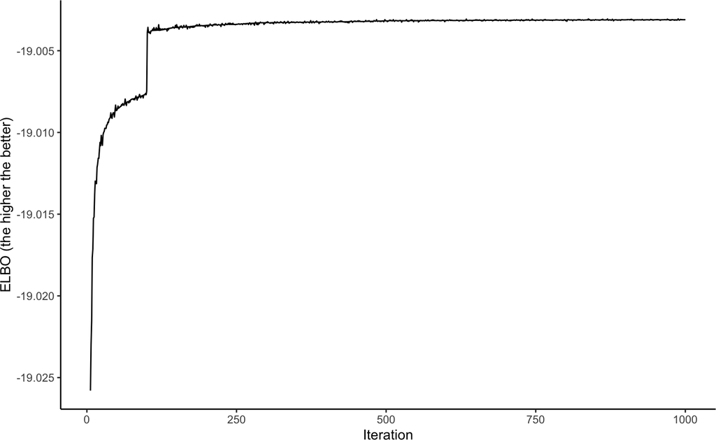

```r
# Fetch elbo
elbo_per_iteration <- MOFAmodel.svi@training_stats[["elbo"]]

# Prepare data.frame for plotting
to.plot <- data.frame(
  iteration = 1:length(elbo_per_iteration),
  elbo = -log2(-elbo_per_iteration)
)
to.plot <- to.plot[to.plot$iteration>5,]

ggplot(to.plot, aes(x=iteration, y=elbo)) +
  geom_line() +
  labs(x="Iteration", y="ELBO (the higher the better)") +
  theme_classic()
```

Plot variance explained estimates

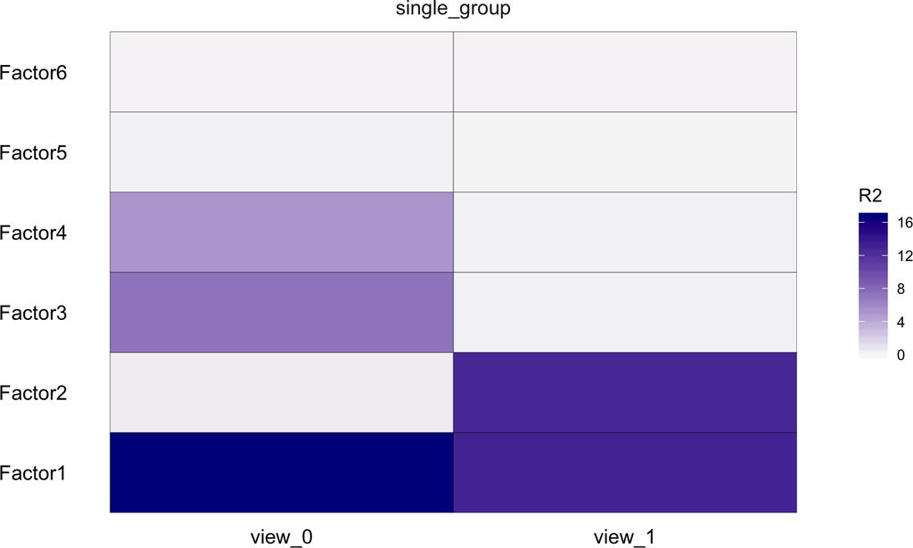

```r
plot_variance_explained(MOFAmodel.svi)
```

Remove factors with very little variance explained

```r
r2 <- calculate_variance_explained(MOFAmodel.svi)[["r2_per_factor"]]

# Calculate average variance explained per factor (across all groups and views)
r2 <- rowMeans( sapply(r2, rowMeans) )

# Subset factors with a minimum variance explained of 1%
MOFAmodel.svi <- subset_factors(MOFAmodel.svi, which(r2>0.01))
```

## 2.6 Fit model using standard variational inference

Let’s fit the same model as before using standard VI

```r
MOFAobject@training_options$stochastic <- FALSE

MOFAobject <- prepare_mofa(MOFAobject)

MOFAmodel.vi <- run_mofa(MOFAobject, outfile)
```

Plot variance explained estimates for VI

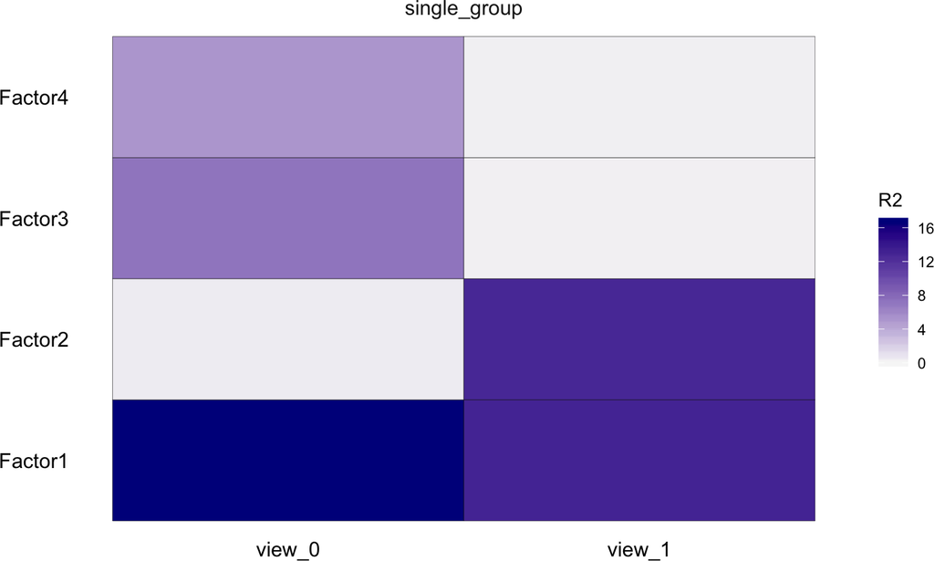

```r
plot_variance_explained(MOFAmodel.vi)
```

Remove factors with very little variance explained

```r
r2 <- calculate_variance_explained(MOFAmodel.vi)[["r2_per_factor"]]

# Calculate average variance explained per factor (across all groups and views)
r2 <- rowMeans( sapply(r2, rowMeans) )

# Subset factors with a minimum variance explained of 1%
MOFAmodel.vi <- subset_factors(MOFAmodel.vi, which(r2>0.01))
```

## 2.7 Comparing VI vs SVI

Compare the factors

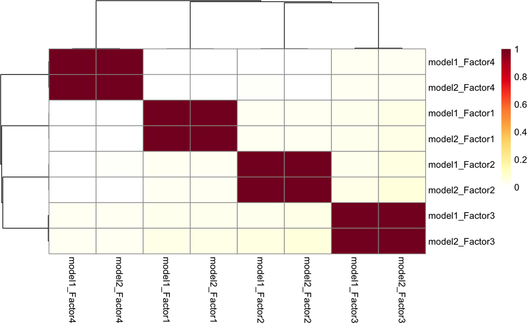

```r
compare_factors(list(MOFAmodel.vi,MOFAmodel.svi))
```

Compare the ELBO

```r
compare_elbo(list("VI"=MOFAmodel.vi, "SVI"=MOFAmodel.svi), log = T)
```

```
## Plotting the log2 of the negative of the ELBO (the higher the better)
```

```
## Plotting the ELBO for every model (the higher the better)
```

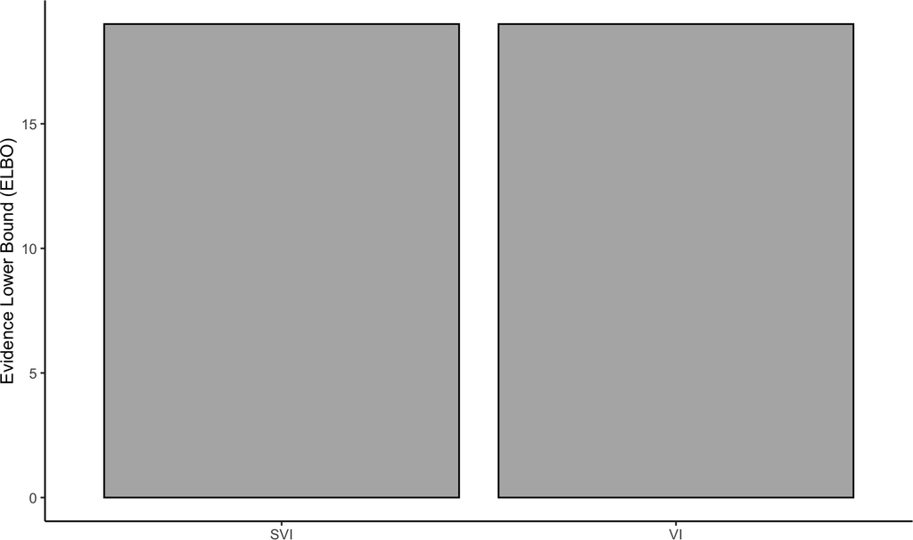

# 3 FAQ

## 3.1 When should I use stochastic inference?

Only when you have a very large data set (N>1e5). Otherwise you should rely on the standard variational inference algorithm.  
Note that you can use GPU-acceleration in either stochastic and non-stochastic mode.

## 3.2 How to optimise the hyperparameters?

The default values we provide tend to yield reasonable estimates, but the optimal settings for your data set may be different. In general, it is good practice to do a grid-search approach and do a proper model selection.  
If you have questions please get in touch with me (ricard@ebi.ac.uk)

## 3.3 Setting up the GPU

MOFA can take advantage of NVIDIA GPUs to massively speed up training. For this you have to install and configure the [cupy](https://docs-cupy.chainer.org/en/stable/install.html) package, which is an open-source matrix library accelerated with NVIDIA CUDA. Please, read their website for installation details.